# Lesson 161 · What is a foundation model?

Standalone Tier C protocol/design exercise. Three live TODOs feed the audit; no model is fitted. Python3.10+ standard library; no downloads. PROVIDED cells supply scaffolding, TODO cells are your functions, CHECK gives immediate feedback, EXIT exports your scoping note. This notebook contains all computation inputs; course links become public only after publication.

**Lesson package** · [Student notebook](https://avistian.github.io/relational/labs/0161-what-is-a-foundation-model.ipynb) · [Executed author preview](https://avistian.github.io/relational/labs/html/0161-what-is-a-foundation-model.html) · [Solution](https://avistian.github.io/relational/labs/solutions/0161-what-is-a-foundation-model.ipynb)  
[Quick reference](https://avistian.github.io/relational/reference/foundation-model-scope.html) · [Scoping note](https://avistian.github.io/relational/labs/l161-scope-template.md) · [Reproduction contract](https://avistian.github.io/relational/labs/l161-reproduction.md) · [Audit output](https://avistian.github.io/relational/labs/evidence/l161/report.md)

## 1 · From one task to a reusable starting point

**Single win:** write a precise, testable scope for a relational foundation model. Read the core lesson in about 20 minutes, then use the notebook and write your note in a separate practice session. Route: define the reusable model → trace adaptation → locate the database boundary → defend a bounded claim.

In [Lesson 159](https://avistian.github.io/relational/lessons/0159-foundation-model-preview.html), predicting masked values supplied a training objective. It did not establish that what was learned helps a new task or database. [Lesson 160](https://avistian.github.io/relational/lessons/0160-year-4-exit-exam.html) separated reproducible computation from sufficient evidence. Year 5 asks what could be reused across tasks, and how to test that reuse. The outstanding Year 4 exit requirements remain outstanding.

> **In plain terms.** A foundation model is a reusable learned starting point. The important questions are what experience produced it and what different jobs it can support.

Bommasani and colleagues describe models trained on broad data and adaptable to a range of downstream tasks. Pretraining creates the reusable model; adaptation makes it useful for a particular task. Large parameter count alone does not supply those properties. The report also emphasizes that a foundation model is an intermediate component, not a complete deployed application. [Primary reading: Bommasani et al., 2021, introduction](https://arxiv.org/abs/2108.07258v1).

A **task** specifies an input, a target and an evaluation rule. **Pretraining** is the earlier learning stage whose result is reused. A **checkpoint** is a saved set of learned parameters, or weights. **Downstream** identifies a later use of that checkpoint. **Transfer** means that prior learning is useful in that later setting; demonstrating benefit needs an appropriate comparison.

**Before the adaptation table.** A label is a known target used for learning or context. A gradient tells an optimizer how to change weights to reduce a chosen loss, the numerical penalty for wrong predictions. A forward pass computes predictions from the current inputs and weights; it need not update those weights. These are separate operations.

**Worked example — a hypothetical research proposal.** Pretrain one checkpoint on databases A and B. Adapt it to customer churn and delivery delay in database C. Compare it with models built independently for those tasks. This proposes reuse across tasks and a database boundary. It does not yet demonstrate either performance gain or sufficient breadth to justify the foundation-model description. Counting databases is not a substitute for explaining their diversity.

## 2 · Follow the information, not the label

**Adaptation** can change weights, add a learned task head, or condition prediction on examples. A **backbone** is the reusable representation-producing part. A **head** maps that representation to a task output. A **context example** is an input with its known target, supplied to inform another prediction. A query is the input whose target is withheld. These routes are discussed in the report's [adaptation overview](https://crfm.stanford.edu/report.html).

| Route in this lesson | Backbone at the target task | Target-specific information |
| --- | --- | --- |
| Fine-tuning | Updated | An adaptation objective, often with labels |
| Frozen encoder + trained head | Frozen | Head updates, often with labels |
| In-context prediction | Frozen | Labeled examples supplied as context |
| Zero-shot prediction | Frozen | No target-task labeled examples or weight updates |

**Zero-shot** here means zero supplied target-task labeled examples. It does not mean no pretraining, no database features or no task description. **Few-shot** describes a small declared label budget; write the actual count, such as eight. It does not uniquely specify an adaptation algorithm. Fine-tuning and in-context prediction can both use eight examples. Our simplified four-route classifier gives weight updates priority for hybrid methods. It records the label count separately and does not classify every possible adaptation technique.

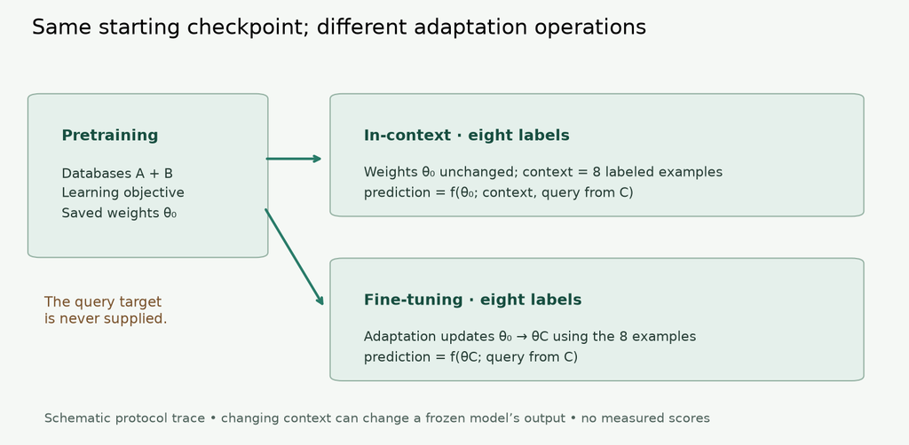

Schematic: both routes start from θ₀ and use eight target labels. In-context prediction changes inputs; fine-tuning changes weights. No model performance is shown.

**Trace the operation.** Write `prediction = f(weights; context, query)`. A semicolon separates learned weights from prediction inputs. Holding weights fixed still allows a changed context to alter the output. By contrast, fine-tuning replaces the initial weights with adapted weights. [Lesson 61's PFN](https://avistian.github.io/relational/lessons/0061-prior-data-fitted-networks.html) called this reuse of learned inference **amortization**: pay the learning cost earlier, then reuse the procedure.

Predict before proceeding: do eight context labels become zero-shot merely because weights stay frozen? Explain.

Static trace: no weight updates + 8 target labels = IN_CONTEXT. Add 20 backbone updates = FINE_TUNING. Remove all labels and updates = ZERO_SHOT.

**What stays fixed in the explorer?** The starting checkpoint and target query. Switch the update rule and label budget; trace which information can change. The explorer reports a protocol classification, not a predicted accuracy.

A no-gradient prediction can still require joins, neighborhood sampling, context construction and expensive attention. “One forward pass” describes a computation strategy; it is not a definition of a foundation model, a guarantee of low latency, or proof that every database fits. “Any database” is an especially strong generalization claim. The ordinary definition allows adaptation and does not require universal schema support.

## 3 · Hold out the right thing

For relational data, specify tables, typed columns, primary/foreign-key links, timestamps and the target entity at its query cutoff. A **foreign key** links a row to a row in another table. A **cutoff** is the time limiting information for a prediction. A **schema** specifies table/column structure and relationships. Transferring to a new schema is a different challenge from predicting new rows in a familiar one.

**Worked example.** A and B are pretraining databases. C supplies eight adaptation labels and disjoint test queries. C can remain held out **from pretraining** while legitimately supplying adaptation examples. If C was actually included in pretraining under an alias, that same test evaluates something else. New test rows cannot undo database-level exposure.

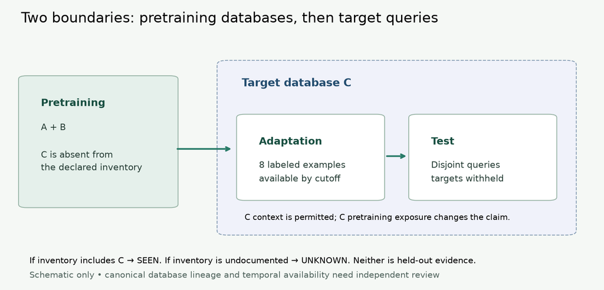

Schematic: target C is absent from pretraining A/B but supplies eight legal adaptation labels. Its test queries remain separate. Declared disjointness still needs a provenance audit.

A useful evaluation has nested boundaries. First separate pretraining databases from the target database. Then, inside the target database, separate adaptation examples, validation decisions and test queries. In temporal tasks, context labels must already be available at each query's cutoff. Labels from the future remain illegal even when called “context.” This is a proposed course evaluation contract, not a benchmark specified by Bommasani's report.

Counterfactual: include C in pretraining A/B and HELD_OUT becomes SEEN. Hide the inventory and it becomes UNKNOWN. Adding legal C adaptation labels alone changes neither membership.

**Interpret the three states.** HELD_OUT means the supplied nonempty inventory excludes C. SEEN means it includes C. UNKNOWN means the inventory is absent or empty. The code cannot discover undisclosed pretraining data, aliases, copies or mislabeled metadata. Canonical database identities must come from a source audit; our fixture names A/B/C are only illustrations. Unknown provenance is not proof of contamination, and it is not proof of independence.

**Broad data requires a written argument.** Discuss domains, schemas, task families and coverage limitations. Synthetic pretraining can cover many generated tasks; a single physical file can encode broad experience. Conversely, many near-duplicate databases can provide little diversity. This lesson deliberately avoids a numerical “FM threshold.”

## 4 · Reuse also shares limitations

The report highlights **emergence**: capabilities arising from the learned system rather than being individually programmed, and **homogenization**: many applications coming to depend on the same underlying model. Shared foundations can spread improvements, but can also transmit defects. The report motivates investigation; these terms do not establish that a particular relational model exhibits a new capability. [Bommasani et al., abstract and introduction](https://arxiv.org/abs/2108.07258v1).

**Relational thought experiment.** Both churn and delivery prediction reuse a representation that discards all but the latest ten transactions. Suppose churn depends on recent activity, but delay depends on a year of recurring disruptions. Reusing the checkpoint does not restore the missing rows. A strong churn result cannot validate the delay task. This is a constructed reasoning example, not a measured failure of a named model.

The practical response is to write falsifiable tests: compare different history requirements, inspect excluded records, and use matched information budgets. Keep the supervised RDL and feature-engineering baselines from Year 4. Foundation-model status alone does not imply superiority over them.

## 5 · Turn a vision into a scope note

Complete [the template](https://avistian.github.io/relational/labs/l161-scope-template.md) in 400–600 words. Make one proposal small enough that its success or failure could be observed.

| Scope field | A reviewable answer must name |
| --- | --- |
| Inputs | Tables, keys, types, time policy, task query and schema limits |
| Pretraining | Corpus identity/version, diversity, objective and checkpoint lineage |
| Adaptation | Updated parameters, label/context count, preprocessing and selection rules |
| Evaluation | Held-out databases, target splits, eligible context and unseen-schema claims |
| Comparison | Baselines with comparable information, labels and declared compute/search budgets |
| Success and failure | Per-task metric, direction, threshold, uncertainty and disconfirming outcome |

**Illustrative success criterion.** On prespecified held-out database C, compare paired MAE differences for delay and paired AUROC differences for churn against the same-label baseline. MAE is average absolute prediction error; lower is better. AUROC measures ranking across positive and negative classes; higher is better. Declare a useful improvement threshold and an uncertainty procedure before test evaluation. Do not average raw MAE and AUROC. Repeated seeds measure some training variation; they do not supply new databases. This is an example of writing a criterion, not a request to run that experiment here.

## 6 · Practice: make the audit resist an attractive claim

The standalone notebook provides **15 synthetic protocol records**. Implement three functions: `adaptation_route`, `database_boundary`, and `scope_verdict`. All three are called by the actual audit. The first two trace information access. The third identifies contradictions in a proposed cross-database comparison: leaked labels, test-led selection, unreviewed time policy, missing matched baseline, lack of a shared initial checkpoint, and a wrongly named adaptation route.

Predict which record fails before each CHECK. Explain why eight legal target-context examples do not imply pretraining overlap. Then change one field in a failed record and explain which issue remains.

**Repair a plan one contradiction at a time.** Start with the otherwise valid A/B → C fixture: zero backbone updates, zero head updates, eight legal adaptation labels, and execution not yet complete. It incorrectly declares zero-shot prediction and selects its settings on test.

| Change | Remaining issue | Status |
| --- | --- | --- |
| Initial plan | Test selection; wrong route name | Revise |
| Select on validation | Wrong route name | Revise |
| Declare in-context prediction | None in this audit | Ready to run |

Renaming the adaptation route fixes a description, not the actual selection leak. Moving selection to validation fixes that separate protocol problem. Eight adaptation labels still do not place C in the pretraining inventory. **Try it:** mark the corrected record completed without attaching predictions. **Check:** its status becomes `READY_FOR_REVIEW`, but transfer performance remains unestablished; the flag requests evidence review and is not evidence itself.

**Status is deliberately narrow.** READY_TO_RUN means the supplied plan passes these consistency rules. READY_FOR_REVIEW means a record also declares execution complete; source artifacts and actual predictions still require inspection. REVISE names remaining contradictions or missing evidence. None establishes the foundation-model label, a measured transfer gain, universal database support or learner mastery. Passing a `temporal_audit=PASS` declaration cannot authenticate an audit.

**Executed author audit:** all 15 synthetic records are included: 4 READY_TO_RUN, 1 READY_FOR_REVIEW and 10 REVISE. These counts describe fixtures, not models or databases. [Complete output](https://avistian.github.io/relational/labs/evidence/l161/report.md).

> **Full-reproduction boundary.** This introductory source is a synthesis report. No named relational numerical benchmark is selected for this lesson, and no report-wide numerical reproduction is claimed. The executable local target is the complete 15-record scope audit. No model is trained. Transfer performance remains NOT_ESTABLISHED. A future performance reproduction needs its own exact paper table, source/code/data pins, all seeds and search trials, and aggregate budget approval. [Contract and source audit](https://avistian.github.io/relational/labs/l161-reproduction.md).

## 7 · Defend, then revisit

Submit the completed notebook and your 400–600-word scope note. A teacher scores definition, data/provenance, adaptation, evaluation, and evidence boundaries from 0–2 each; target at least 8/10 with no zero. Automated checks are feedback, not a substitute for this review. Learner status stays PENDING_WRITTEN_DEFENSE until your own submission is assessed.

Explain which evidence would justify unseen-database transfer and which unknowns remain. Ask the teaching agent to assess your 400–600-word scope.

Tomorrow, reconstruct the four adaptation routes without looking. In one week, audit a proposal whose target database was renamed before pretraining. Ask the teaching agent about any unclear step or paste your scope note for feedback.

**Read next:** the introduction and adaptation discussion of [Bommasani et al. (2021)](https://arxiv.org/abs/2108.07258v1), with the [author overview](https://crfm.stanford.edu/report.html). [Lesson 162](https://avistian.github.io/relational/lessons/0162-the-relational-fm-vision.html) applies this scope to the relational foundation-model vision. Read Year 5 concepts while preserving Year 4's pending evidence gates.

```python
# @colab-bootstrap — PROVIDED: standard library only, no network or package installs.
from pathlib import Path
from copy import deepcopy
import hashlib,json
```

## PROVIDED · Immutable synthetic inputs

A/B/C are fictional canonical database identities. Every record is declared metadata, including the completed example; there are no measured prediction files.

```python
fixture_text = '{\n  "kind": "SYNTHETIC_PROTOCOL_FIXTURES",\n  "cases": [\n    {\n      "name": "declared_plan",\n      "record": {\n        "pretraining_databases": [\n          "A",\n          "B"\n        ],\n        "evaluation_database": "C",\n        "backbone_updates": 0,\n        "head_updates": 0,\n        "target_labels": 8,\n        "declared_mode": "IN_CONTEXT",\n        "selection_split": "validation",\n        "evaluation_split": "test",\n        "test_labels_used": false,\n        "temporal_audit": "PASS",\n        "baseline_matched": true,\n        "completed": false,\n        "checkpoint_shared": true\n      },\n      "expected": "READY_TO_RUN"\n    },\n    {\n      "name": "completed_hypothetical",\n      "record": {\n        "pretraining_databases": [\n          "A",\n          "B"\n        ],\n        "evaluation_database": "C",\n        "backbone_updates": 0,\n        "head_updates": 0,\n        "target_labels": 8,\n        "declared_mode": "IN_CONTEXT",\n        "selection_split": "validation",\n        "evaluation_split": "test",\n        "test_labels_used": false,\n        "temporal_audit": "PASS",\n        "baseline_matched": true,\n        "completed": true,\n        "checkpoint_shared": true\n      },\n      "expected": "READY_FOR_REVIEW"\n    },\n    {\n      "name": "known_overlap",\n      "record": {\n        "pretraining_databases": [\n          "A",\n          "C"\n        ],\n        "evaluation_database": "C",\n        "backbone_updates": 0,\n        "head_updates": 0,\n        "target_labels": 8,\n        "declared_mode": "IN_CONTEXT",\n        "selection_split": "validation",\n        "evaluation_split": "test",\n        "test_labels_used": false,\n        "temporal_audit": "PASS",\n        "baseline_matched": true,\n        "completed": false,\n        "checkpoint_shared": true\n      },\n      "expected": "REVISE"\n    },\n    {\n      "name": "unknown_inventory",\n      "record": {\n        "pretraining_databases": null,\n        "evaluation_database": "C",\n        "backbone_updates": 0,\n        "head_updates": 0,\n        "target_labels": 8,\n        "declared_mode": "IN_CONTEXT",\n        "selection_split": "validation",\n        "evaluation_split": "test",\n        "test_labels_used": false,\n        "temporal_audit": "PASS",\n        "baseline_matched": true,\n        "completed": false,\n        "checkpoint_shared": true\n      },\n      "expected": "REVISE"\n    },\n    {\n      "name": "empty_inventory",\n      "record": {\n        "pretraining_databases": [],\n        "evaluation_database": "C",\n        "backbone_updates": 0,\n        "head_updates": 0,\n        "target_labels": 8,\n        "declared_mode": "IN_CONTEXT",\n        "selection_split": "validation",\n        "evaluation_split": "test",\n        "test_labels_used": false,\n        "temporal_audit": "PASS",\n        "baseline_matched": true,\n        "completed": false,\n        "checkpoint_shared": true\n      },\n      "expected": "REVISE"\n    },\n    {\n      "name": "test_selection",\n      "record": {\n        "pretraining_databases": [\n          "A",\n          "B"\n        ],\n        "evaluation_database": "C",\n        "backbone_updates": 0,\n        "head_updates": 0,\n        "target_labels": 8,\n        "declared_mode": "IN_CONTEXT",\n        "selection_split": "test",\n        "evaluation_split": "test",\n        "test_labels_used": false,\n        "temporal_audit": "PASS",\n        "baseline_matched": true,\n        "completed": false,\n        "checkpoint_shared": true\n      },\n      "expected": "REVISE"\n    },\n    {\n      "name": "test_label_leak",\n      "record": {\n        "pretraining_databases": [\n          "A",\n          "B"\n        ],\n        "evaluation_database": "C",\n        "backbone_updates": 0,\n        "head_updates": 0,\n        "target_labels": 8,\n        "declared_mode": "IN_CONTEXT",\n        "selection_split": "validation",\n        "evaluation_split": "test",\n        "test_labels_used": true,\n        "temporal_audit": "PASS",\n        "baseline_matched": true,\n        "completed": false,\n        "checkpoint_shared": true\n      },\n      "expected": "REVISE"\n    },\n    {\n      "name": "validation_only",\n      "record": {\n        "pretraining_databases": [\n          "A",\n          "B"\n        ],\n        "evaluation_database": "C",\n        "backbone_updates": 0,\n        "head_updates": 0,\n        "target_labels": 8,\n        "declared_mode": "IN_CONTEXT",\n        "selection_split": "validation",\n        "evaluation_split": "validation",\n        "test_labels_used": false,\n        "temporal_audit": "PASS",\n        "baseline_matched": true,\n        "completed": false,\n        "checkpoint_shared": true\n      },\n      "expected": "REVISE"\n    },\n    {\n      "name": "unknown_arrival",\n      "record": {\n        "pretraining_databases": [\n          "A",\n          "B"\n        ],\n        "evaluation_database": "C",\n        "backbone_updates": 0,\n        "head_updates": 0,\n        "target_labels": 8,\n        "declared_mode": "IN_CONTEXT",\n        "selection_split": "validation",\n        "evaluation_split": "test",\n        "test_labels_used": false,\n        "temporal_audit": "NOT_ESTABLISHED",\n        "baseline_matched": true,\n        "completed": false,\n        "checkpoint_shared": true\n      },\n      "expected": "REVISE"\n    },\n    {\n      "name": "unmatched_baseline",\n      "record": {\n        "pretraining_databases": [\n          "A",\n          "B"\n        ],\n        "evaluation_database": "C",\n        "backbone_updates": 0,\n        "head_updates": 0,\n        "target_labels": 8,\n        "declared_mode": "IN_CONTEXT",\n        "selection_split": "validation",\n        "evaluation_split": "test",\n        "test_labels_used": false,\n        "temporal_audit": "PASS",\n        "baseline_matched": false,\n        "completed": false,\n        "checkpoint_shared": true\n      },\n      "expected": "REVISE"\n    },\n    {\n      "name": "new_model_each_task",\n      "record": {\n        "pretraining_databases": [\n          "A",\n          "B"\n        ],\n        "evaluation_database": "C",\n        "backbone_updates": 0,\n        "head_updates": 0,\n        "target_labels": 8,\n        "declared_mode": "IN_CONTEXT",\n        "selection_split": "validation",\n        "evaluation_split": "test",\n        "test_labels_used": false,\n        "temporal_audit": "PASS",\n        "baseline_matched": true,\n        "completed": false,\n        "checkpoint_shared": false\n      },\n      "expected": "REVISE"\n    },\n    {\n      "name": "false_zero_shot",\n      "record": {\n        "pretraining_databases": [\n          "A",\n          "B"\n        ],\n        "evaluation_database": "C",\n        "backbone_updates": 0,\n        "head_updates": 0,\n        "target_labels": 8,\n        "declared_mode": "ZERO_SHOT",\n        "selection_split": "validation",\n        "evaluation_split": "test",\n        "test_labels_used": false,\n        "temporal_audit": "PASS",\n        "baseline_matched": true,\n        "completed": false,\n        "checkpoint_shared": true\n      },\n      "expected": "REVISE"\n    },\n    {\n      "name": "fine_tuning",\n      "record": {\n        "pretraining_databases": [\n          "A",\n          "B"\n        ],\n        "evaluation_database": "C",\n        "backbone_updates": 20,\n        "head_updates": 0,\n        "target_labels": 8,\n        "declared_mode": "FINE_TUNING",\n        "selection_split": "validation",\n        "evaluation_split": "test",\n        "test_labels_used": false,\n        "temporal_audit": "PASS",\n        "baseline_matched": true,\n        "completed": false,\n        "checkpoint_shared": true\n      },\n      "expected": "READY_TO_RUN"\n    },\n    {\n      "name": "frozen_head",\n      "record": {\n        "pretraining_databases": [\n          "A",\n          "B"\n        ],\n        "evaluation_database": "C",\n        "backbone_updates": 0,\n        "head_updates": 20,\n        "target_labels": 8,\n        "declared_mode": "FROZEN_ENCODER_HEAD",\n        "selection_split": "validation",\n        "evaluation_split": "test",\n        "test_labels_used": false,\n        "temporal_audit": "PASS",\n        "baseline_matched": true,\n        "completed": false,\n        "checkpoint_shared": true\n      },\n      "expected": "READY_TO_RUN"\n    },\n    {\n      "name": "zero_shot",\n      "record": {\n        "pretraining_databases": [\n          "A",\n          "B"\n        ],\n        "evaluation_database": "C",\n        "backbone_updates": 0,\n        "head_updates": 0,\n        "target_labels": 0,\n        "declared_mode": "ZERO_SHOT",\n        "selection_split": "validation",\n        "evaluation_split": "test",\n        "test_labels_used": false,\n        "temporal_audit": "PASS",\n        "baseline_matched": true,\n        "completed": false,\n        "checkpoint_shared": true\n      },\n      "expected": "READY_TO_RUN"\n    }\n  ]\n}\n'
assert hashlib.sha256(fixture_text.encode()).hexdigest()=='3a993a0d3bd3f49a0de4c6dc9a6dbb9d041380aaecd9fd8054f2059b77838c2b'
packet=json.loads(fixture_text)
print("Loaded",len(packet["cases"]),"synthetic protocol records")
```

```
Loaded 15 synthetic protocol records
```

```python
def example_record():
    return dict(pretraining_databases=['A','B'],evaluation_database='C',
                backbone_updates=0,head_updates=0,target_labels=8,
                declared_mode='IN_CONTEXT',selection_split='validation',evaluation_split='test',
                test_labels_used=False,temporal_audit='PASS',baseline_matched=True,
                completed=False,checkpoint_shared=True)
```

## TODO · adaptation_route

**Goal:** Trace changed weights and supplied labels.

**Why:** Accept nonnegative integer backbone/head update counts and target label count; reject booleans and invalid counts. Return one of the four uppercase route names. Backbone updates take priority over head updates, then distinguish context examples from zero-shot. Counts describe target adaptation, not pretraining.

Predict a contradictory record before implementing.

```python
def adaptation_route(backbone_updates, head_updates, target_labels):
    """Describe a simplified adaptation route, with weight updates taking priority.

Counts cover target-task adaptation, not original pretraining. Target labels
include all target-task examples supplied to the learner, not test outcomes.
Hybrid prompting plus fine-tuning is reported under FINE_TUNING.
"""
    counts = (backbone_updates, head_updates, target_labels)
    if any(type(x) is not int or x < 0 for x in counts):
        raise ValueError('Update and label counts must be nonnegative integers')
    if backbone_updates:
        return 'FINE_TUNING'
    if head_updates:
        return 'FROZEN_ENCODER_HEAD'
    return 'IN_CONTEXT' if target_labels else 'ZERO_SHOT'
```

```python
# CHECK
assert adaptation_route(0,0,8)=="IN_CONTEXT"
assert adaptation_route(20,0,8)=="FINE_TUNING"
print("CHECK: same eight labels, different update route")
```

```
CHECK: same eight labels, different update route
```

## TODO · database_boundary

**Goal:** Protect database identity, not just row identity.

**Why:** Accept a canonical pretraining list (or None) and a nonempty target database ID. Missing or empty inventory is UNKNOWN. Known membership is SEEN, known absence is HELD_OUT. Reject duplicates, whitespace aliases and non-string IDs; reject a string used as a list. Do not infer provenance from labels.

Predict a contradictory record before implementing.

```python
def database_boundary(pretraining_databases, evaluation_database):
    """Check pretraining membership; target adaptation is deliberately separate."""
    if not isinstance(evaluation_database, str) or not evaluation_database or evaluation_database.strip() != evaluation_database:
        raise ValueError('Use a nonempty canonical evaluation database ID')
    if pretraining_databases is None:
        return 'UNKNOWN'
    if not isinstance(pretraining_databases, list):
        raise ValueError('Pretraining inventory must be a list or None')
    if any(not isinstance(x, str) or not x or x.strip() != x for x in pretraining_databases):
        raise ValueError('Use nonempty canonical pretraining database IDs')
    if len(set(pretraining_databases)) != len(pretraining_databases):
        raise ValueError('Duplicate IDs: resolve database lineage before counting')
    if not pretraining_databases:
        return 'UNKNOWN'
    return 'SEEN' if evaluation_database in pretraining_databases else 'HELD_OUT'
```

```python
# CHECK
assert database_boundary(["A","B"],"C")=="HELD_OUT"
assert database_boundary(None,"C")=="UNKNOWN"
print("CHECK: undocumented is not disjoint")
```

```
CHECK: undocumented is not disjoint
```

## TODO · scope_verdict

**Goal:** Match the declaration to the proposed cross-database experiment.

**Why:** Validate required fields and types as specified below. Call route then boundary exactly once using supplied callbacks. Collect all issues, never only the first. REVISE if any issue exists; otherwise READY_FOR_REVIEW if completed, READY_TO_RUN if not. Return mode, pretraining_boundary, status, issues, universal_claim=NOT_ESTABLISHED and learner=PENDING_WRITTEN_DEFENSE. Do not mutate input.

Predict a contradictory record before implementing. Required record fields: pretraining_databases, evaluation_database, backbone_updates, head_updates, target_labels, declared_mode, selection_split, evaluation_split, test_labels_used, temporal_audit, baseline_matched, completed, checkpoint_shared. The four flags are strict Booleans; splits are train/validation/test; temporal_audit is PASS/FAIL/NOT_ESTABLISHED; declared_mode is a known route. Raise ValueError for malformed records. Callback validation handles counts and database IDs.

Diagnostic mapping: unknown corpus → PRETRAINING_UNKNOWN; target in corpus → PRETRAINING_OVERLAP; test selection → TEST_SELECTION; evaluation other than test → NO_HELD_OUT_TEST; test labels used → TEST_LABEL_ACCESS; temporal status other than PASS → TEMPORAL_UNVERIFIED; unmatched baseline → BASELINE_UNMATCHED; separately initialized task models → NO_SHARED_CHECKPOINT; declared versus computed mode disagreement → MODE_MISMATCH. Emit in this order. Training-only prespecified selection is allowed; test selection is not. PASS is a declaration that needs external evidence.

```python
def scope_verdict(record, route=adaptation_route, boundary=database_boundary):
    """Audit a declared held-out-database comparison; never certify a model.

READY_FOR_REVIEW means the supplied metadata is internally consistent. It
requires independent source, prediction and provenance review before any claim.
"""
    required = {'pretraining_databases','evaluation_database','backbone_updates',
                'head_updates','target_labels','declared_mode','selection_split',
                'evaluation_split','test_labels_used','temporal_audit',
                'baseline_matched','completed','checkpoint_shared'}
    if not isinstance(record, dict) or not required <= record.keys():
        raise ValueError('Missing scope fields')
    for key in ['test_labels_used','baseline_matched','completed','checkpoint_shared']:
        if type(record[key]) is not bool:
            raise ValueError(key + ' must be a Boolean')
    if record['temporal_audit'] not in ['PASS','FAIL','NOT_ESTABLISHED']:
        raise ValueError('Unknown temporal audit status')
    if record['selection_split'] not in ['train','validation','test'] or record['evaluation_split'] not in ['train','validation','test']:
        raise ValueError('Unknown split')
    if record['declared_mode'] not in ['ZERO_SHOT','IN_CONTEXT','FROZEN_ENCODER_HEAD','FINE_TUNING']:
        raise ValueError('Unknown adaptation declaration')
    mode = route(record['backbone_updates'], record['head_updates'], record['target_labels'])
    membership = boundary(record['pretraining_databases'], record['evaluation_database'])
    issues = []
    if membership == 'UNKNOWN': issues.append('PRETRAINING_UNKNOWN')
    if membership == 'SEEN': issues.append('PRETRAINING_OVERLAP')
    if record['selection_split'] == 'test': issues.append('TEST_SELECTION')
    if record['evaluation_split'] != 'test': issues.append('NO_HELD_OUT_TEST')
    if record['test_labels_used']: issues.append('TEST_LABEL_ACCESS')
    if record['temporal_audit'] != 'PASS': issues.append('TEMPORAL_UNVERIFIED')
    if not record['baseline_matched']: issues.append('BASELINE_UNMATCHED')
    if not record['checkpoint_shared']: issues.append('NO_SHARED_CHECKPOINT')
    if mode != record['declared_mode']: issues.append('MODE_MISMATCH')
    status = 'REVISE' if issues else 'READY_FOR_REVIEW' if record['completed'] else 'READY_TO_RUN'
    return dict(mode=mode, pretraining_boundary=membership, status=status, issues=issues,
                universal_claim='NOT_ESTABLISHED', learner='PENDING_WRITTEN_DEFENSE')
```

```python
# CHECK
r=example_record()
assert scope_verdict(r)["status"]=="READY_TO_RUN"
r["test_labels_used"]=True
assert "TEST_LABEL_ACCESS" in scope_verdict(r)["issues"]
print("CHECK: planned completion does not erase leaked labels")
```

```
CHECK: planned completion does not erase leaked labels
```

## PROVIDED · Full audit and adversarial feedback

These functions call your three implementations. READY_FOR_REVIEW is a conditional design verdict. It is never a measured score or a foundation-model certification.

```python
def audit161(packet, route, boundary, verdict):
    rows=[]
    for case in packet['cases']:
        answer=verdict(case['record'],route=route,boundary=boundary)
        rows.append(dict(name=case['name'],**answer))
    return dict(experiment='L161 Relational Foundation-Model Scope Audit',
                data_kind=packet['kind'],cases=len(rows),rows=rows,
                training='NOT_RUN',paper_performance_reproduction='NOT_APPLICABLE_TO_SELECTED_CONCEPT_SCOPE',
                transfer_performance='NOT_ESTABLISHED',cloud_spend_usd=0,
                learner='PENDING_WRITTEN_DEFENSE')
```

```python
def render161(report):
    lines=['# L161 declared-protocol audit','',
           'Synthetic metadata only. READY_FOR_REVIEW is conditional on supplied facts, not verified performance.',
           '', '| Case | Adaptation | Pretraining boundary | Design status |',
           '|---|---|---|---|']
    lines += [f"| {r['name']} | {r['mode']} | {r['pretraining_boundary']} | {r['status']} |" for r in report['rows']]
    return '\n'.join(lines)+'\n\nNo training, transfer measurement or learner mastery is established. Cloud spend USD0.\n'
```

```python
def check161(route,boundary,verdict):
    assert route(0,0,0)=='ZERO_SHOT'
    assert route(0,0,8)=='IN_CONTEXT'
    assert route(0,20,8)=='FROZEN_ENCODER_HEAD'
    assert route(20,20,8)=='FINE_TUNING'
    assert route(1,0,0)=='FINE_TUNING', 'Unsupervised adaptation can update weights without target labels'
    for bad in [-1,True,0.5,'8',None]:
        try: route(0,0,bad)
        except ValueError: pass
        else: raise AssertionError('Invalid count accepted')
    assert boundary(['A','B'],'C')=='HELD_OUT'
    assert boundary(['A','B'],'A')=='SEEN'
    assert boundary(None,'C')=='UNKNOWN'
    assert boundary([],'C')=='UNKNOWN', 'Empty corpus does not document broad pretraining'
    for corpus,target in [(['A','A'],'C'),([' A'],'C'),('AB','C'),(['A'],''),([1],'C')]:
        try: boundary(corpus,target)
        except ValueError: pass
        else: raise AssertionError('Ambiguous database identity accepted')
    base=example_record()
    assert verdict(base)['status']=='READY_TO_RUN', 'A plan is not a measured experiment'
    done=deepcopy(base);done['completed']=True
    assert verdict(done)['status']=='READY_FOR_REVIEW'
    assert verdict(done)['universal_claim']=='NOT_ESTABLISHED'
    assert verdict(done)['learner']=='PENDING_WRITTEN_DEFENSE'
    changes=[('pretraining_databases',None,'PRETRAINING_UNKNOWN'),
             ('pretraining_databases',['A','C'],'PRETRAINING_OVERLAP'),
             ('selection_split','test','TEST_SELECTION'),
             ('evaluation_split','validation','NO_HELD_OUT_TEST'),
             ('test_labels_used',True,'TEST_LABEL_ACCESS'),
             ('temporal_audit','NOT_ESTABLISHED','TEMPORAL_UNVERIFIED'),
             ('baseline_matched',False,'BASELINE_UNMATCHED'),
             ('checkpoint_shared',False,'NO_SHARED_CHECKPOINT'),
             ('declared_mode','ZERO_SHOT','MODE_MISMATCH')]
    for field,value,issue in changes:
        r=deepcopy(done);r[field]=value
        answer=verdict(r)
        assert answer['status']=='REVISE' and issue in answer['issues'], (field,answer)
    assert base==example_record(), 'Auditor must not mutate input'
    for field,value in [('completed','yes'),('temporal_audit','maybe'),('target_labels',False),('declared_mode','magic')]:
        r=deepcopy(base);r[field]=value
        try: verdict(r)
        except ValueError: pass
        else: raise AssertionError('Malformed record accepted: '+field)
    observed=[]
    def routed(*args): observed.append('route');return route(*args)
    def bounded(*args): observed.append('boundary');return boundary(*args)
    verdict(base,route=routed,boundary=bounded)
    assert observed==['route','boundary'], 'The real adapter must call the learner functions'
    return 'PASS'
```

```python
# CHECK — execute every declared case through the live learner functions
assert check161(adaptation_route,database_boundary,scope_verdict)=="PASS"
report=audit161(packet,adaptation_route,database_boundary,scope_verdict)
assert all(row["status"]==case["expected"] for row,case in zip(report["rows"],packet["cases"]))
print(render161(report))
Path("l161-report.json").write_text(json.dumps(report,indent=2)+"\n")
```

```
# L161 declared-protocol audit

Synthetic metadata only. READY_FOR_REVIEW is conditional on supplied facts, not verified performance.

| Case | Adaptation | Pretraining boundary | Design status |
|---|---|---|---|
| declared_plan | IN_CONTEXT | HELD_OUT | READY_TO_RUN |
| completed_hypothetical | IN_CONTEXT | HELD_OUT | READY_FOR_REVIEW |
| known_overlap | IN_CONTEXT | SEEN | REVISE |
| unknown_inventory | IN_CONTEXT | UNKNOWN | REVISE |
| empty_inventory | IN_CONTEXT | UNKNOWN | REVISE |
| test_selection | IN_CONTEXT | HELD_OUT | REVISE |
| test_label_leak | IN_CONTEXT | HELD_OUT | REVISE |
| validation_only | IN_CONTEXT | HELD_OUT | REVISE |
| unknown_arrival | IN_CONTEXT | HELD_OUT | REVISE |
| unmatched_baseline | IN_CONTEXT | HELD_OUT | REVISE |
| new_model_each_task | IN_CONTEXT | HELD_OUT | REVISE |
| false_zero_shot | IN_CONTEXT | HELD_OUT | REVISE |
| fine_tuning | FINE_TUNING | HELD_OUT | READY_TO_RUN |
| frozen_head | FROZEN_ENCODER_HEAD | HELD_OUT | READY_TO_RUN |
| zero_shot | ZERO_SHOT | HELD_OUT | READY_TO_RUN |

No training, transfer measurement or learner mastery is established. Cloud spend USD0.
```

```
4481
```

## EXIT · Your 400–600-word proposal

Use the six scope fields above. A teacher assesses definition, provenance, adaptation, evaluation and boundaries (0–2 each; ≥8/10 and no zero). Code checks cannot validate the prose or authenticate the metadata. The short author example below is only an illustration; replace it with your own defended scope.

```python
written_scope = 'I propose reusing one pretrained checkpoint across churn and delay tasks in a declared held-out database. The pretraining inventory and schema coverage must be audited before claiming transfer. Eight legal context labels define the adaptation budget; no task weight updates are planned. Separate test queries and validation-only selection preserve the evaluation boundary. Compare paired task metrics against the same-label baseline and preregister useful-effect thresholds. At present these are metadata fixtures. No trained model, transfer gain, universal schema support or completed learner defense is established.'
my_protocol = example_record()  # Replace with your proposal; do not invent provenance.
my_audit = scope_verdict(my_protocol)
submission=dict(written_scope=written_scope,declared_protocol=my_protocol,audit=my_audit,review=None,learner="PENDING_WRITTEN_DEFENSE")
Path("l161-submission.json").write_text(json.dumps(submission,indent=2)+"\n")
print("Exported scope; learner PENDING_WRITTEN_DEFENSE")
```

```
Exported scope; learner PENDING_WRITTEN_DEFENSE
```

## NEXT STEP · A performance reproduction needs a different contract

The Bommasani report supplies this lesson’s concepts, not a selected relational training recipe. Name an exact published model/table, pin its code, corpus, splits, preprocessing, adaptation, selection, all seeds and metric aggregation; budget the complete run plus validation and retries before requesting authorization. Do not relabel these 15 synthetic metadata records as model or paper performance. Ask the teaching agent to review your note.